# supplement 7

Steve Simon

June 2, 2018

This file creates various formulas and graphs needed to illustrate the underlying theory behind the data analyses in survival-lecture-7.Rmd. I am sharing this for those who are curious, but you are not responsible for learning or using the code shown in this supplement.

This file does not need any special libraries other than the ones listed below. Many of the data sets in this program use data from Hosmer, Lemeshow, and May.

```r
library(broom)
library(coxme)
library(dplyr)
```

```r
library(ggplot2)
library(magrittr)
library(survival)
library(tidyr)
```

## Interval censored data

An event is said to be interval censored in the interval (a,b) if you know that the event did not occur before time a and that it did occur before time b.

A right censored observation is equivalent to interval censoring on the interval (a, $\infty$).

A left censored observation is equivalent to interval censoring on the interval (0, b).

The likelihood in most settings is the product of the density functions, but with interval censoring, you replace the density by

$\int_a^b f(t; \beta) = S(a; \beta)-S(b; \beta)$

## Left truncation

In most studies, patients are considered part of the risk set from time 0 to the time that they either die or are censored. But sometimes patients start contributing information about survival only from a certain point forward. This is left truncation.

Here’s an example from

math.usu.edu/jrstevens/biostat/projects2013/pres_LeftTruncation.pdf

```r
par(mar=c(2.6, 2.6, 0.6, 0.6), las=1)
fn <- "~/survival-models/bin/psychiatric.RData"
load(fn)
head(psychiatric)
```

```
##      sex age time  death age2
## 1 female  51    1  death   52
## 2 female  58    1  death   59
## 3 female  55    2  death   57
## 4 female  28   22  death   50
## 5   male  21   30 censor   51
## 6   male  19   28  death   47
```

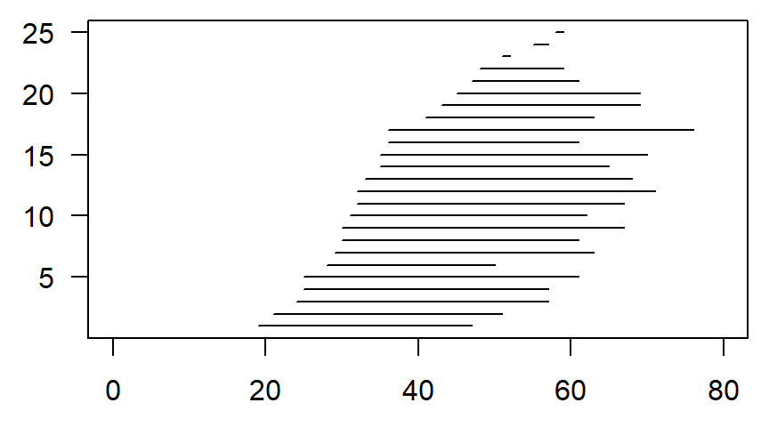

```r
psychiatric %<>% arrange(age, age2)
n <- dim(psychiatric)[1]
n_atrisk <- rep(NA, 80)
for (i in 1:80) {
  n_atrisk[i] <- sum((psychiatric$age<=i) - (psychiatric$age2<=i))
}
plot(c(0, 80), c(1,n), type="n")
segments(psychiatric$age, 1:n, psychiatric$age2, 1:n)
```

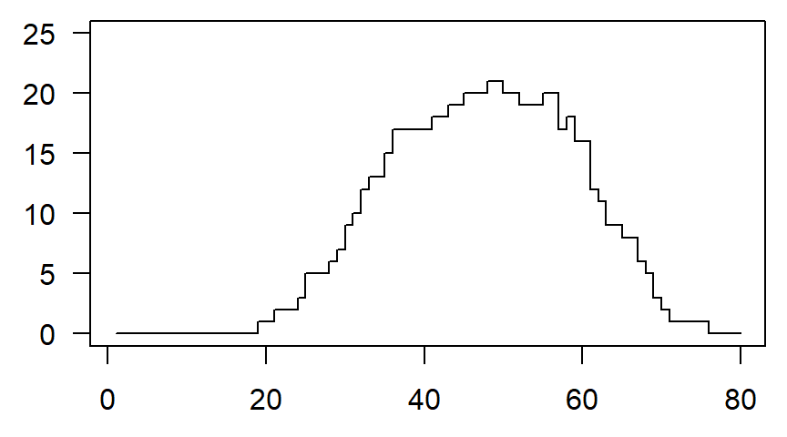

```r
plot(1:80, n_atrisk, type="s", ylim=c(0,25))
```

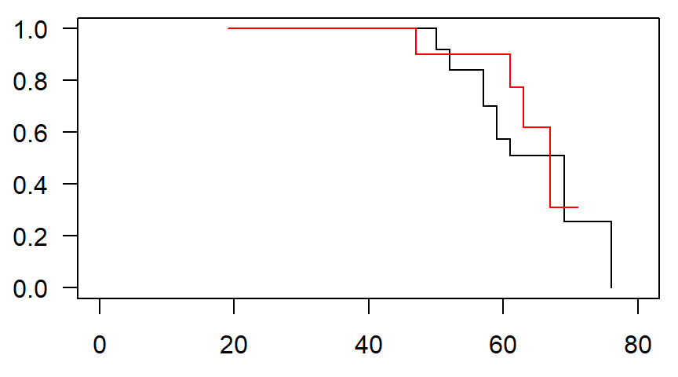

```r
psychiatric              %$%
  Surv(age, age2, death=="death") -> psychiatric_surv
survfit(psychiatric_surv~psychiatric$sex)    %>%
  tidy                                       -> psychiatric_km
m <- psychiatric_km$strata=="psychiatric$sex=male"
f <- psychiatric_km$strata=="psychiatric$sex=female"
plot(c(0, 80), c(0, 1), type="n")
lines(
  psychiatric_km$time[f],
  psychiatric_km$estimate[f],
  type="s")
lines(
  psychiatric_km$time[m],
  psychiatric_km$estimate[m],
  type="s", col="red")
```

## Sandwich estimate

You can account for cluster effects by modifying the variance-covariance of the coefficients. For the normal model without frailty effects, the information matrix is

$I(\beta) = \frac{\partial^2 L_p}{(\partial \beta)^2}$

and the estimated variance covariance matrix, $\hat{V}$, is

$\hat{V} = I(\hat{\beta})^{-1}$

The robust sandwich estimator (similar to the sandwich estimator in Generalized Estimating Equations) is

$\hat{R} = \hat{V} (\hat{L}'\hat{L}) \hat{V}$

where $\hat{L}$ is the vector of Schoenfeld residuals. The middle of this sandwich, the $\hat{L}'\hat{L}$, adjusts the variance covariance matrix to account for the correlation within clusters.

## Frailty model

The frailty model introduces a random effect, called a frailty term, $z_f$. Recall that the proportional hazards model assumes that the hazard function of a given patient,

$h(t, X, \beta) = h_0(t) e^{X \beta}$

The frailty model multiplies all the hazards within a family f by $z_f$. In other words,

$h(t, X, \beta) = z_f h_0(t) e^{X \beta}$

Typically, $z_f$ is given a gamma distribution with a mean of 1 and a variance of $\theta$.

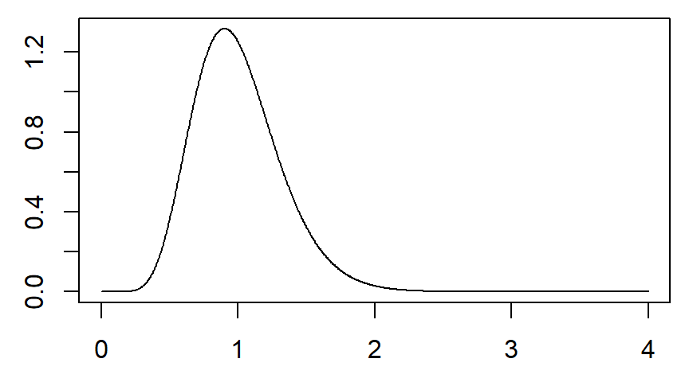

```r
par(mar=c(2.6, 2.6, 0.6, 0.6))
alpha <- 10
x <- seq(0.001, 4, length=1000)
plot(x, dgamma(x, alpha, rate=alpha),
  type="l", xlim=c(0, 4), ylimm=c(0, 1.3))
```

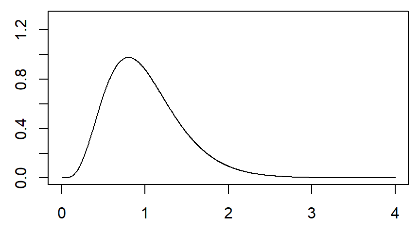

```r
alpha <- 5
plot(x, dgamma(x, alpha, rate=alpha),
  type="l", xlim=c(0, 4), ylim=c(0, 1.3))
```

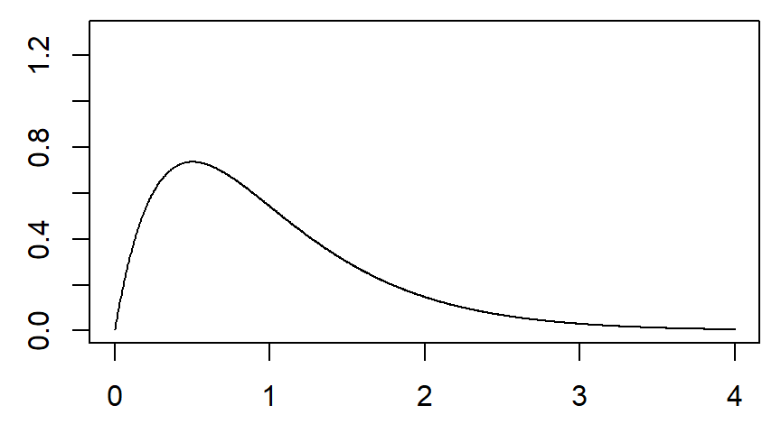

```r
alpha <- 2
plot(x, dgamma(x, alpha, rate=alpha),
  type="l", xlim=c(0, 4), ylim=c(0, 1.3))
```

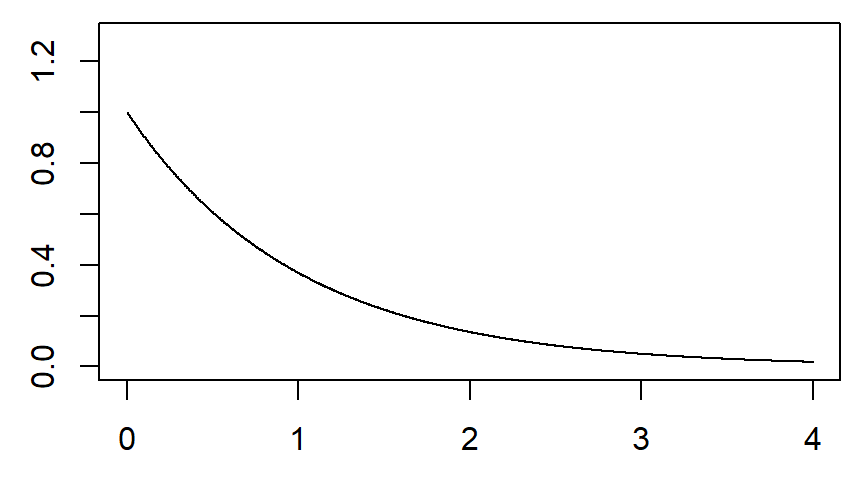

```r
alpha <- 1
plot(x, dgamma(x, alpha, rate=alpha),
  type="l", xlim=c(0, 4), ylim=c(0, 1.3))
```

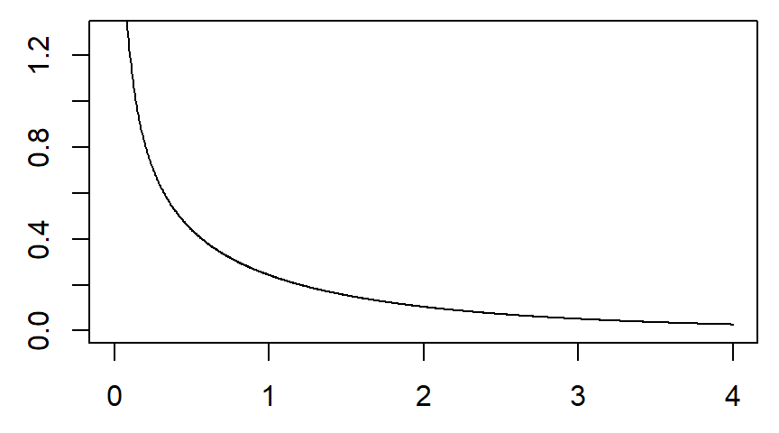

```r
alpha <- 0.5
plot(x, dgamma(x, alpha, rate=alpha),
  type="l", xlim=c(0, 4), ylim=c(0, 1.3))
```

## Examples

The asaur package has all the data sets using in the book Applied Survival Analysis Using R, by Dirk F. Moore.

```r
library(asaur)
head(ashkenazi)
```

```
##   famID brcancer age mutant
## 1     1        0  73      0
## 2     1        0  40      0
## 3     7        0  48      0
## 4     7        0  25      0
## 5     8        0  56      0
## 6     8        0  55      0
```

```r
table(table(ashkenazi$famID))
```

```
##
##    2
## 1960
```

```r
table(ashkenazi$brcancer)
```

```
##
##    0    1
## 3447  473
```

```r
table(ashkenazi$mutant)
```

```
##
##    0    1
## 3830   90
```

```r
summary(ashkenazi$age)
```

```
##    Min. 1st Qu.  Median    Mean 3rd Qu.    Max.
##    1.00   45.00   59.00   58.63   73.00  100.00
```

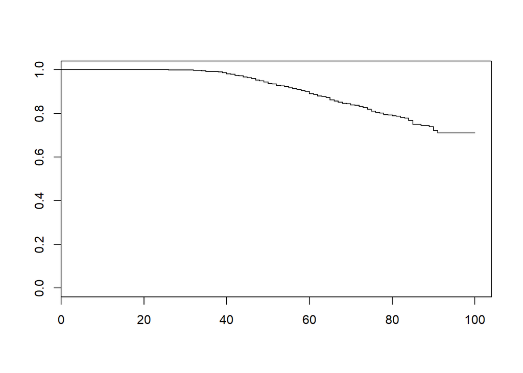

```r
bc_surv <- Surv(ashkenazi$age, ashkenazi$brcancer)
km_overall <- survfit(bc_surv~1)
plot(km_overall, conf.int=FALSE)
```

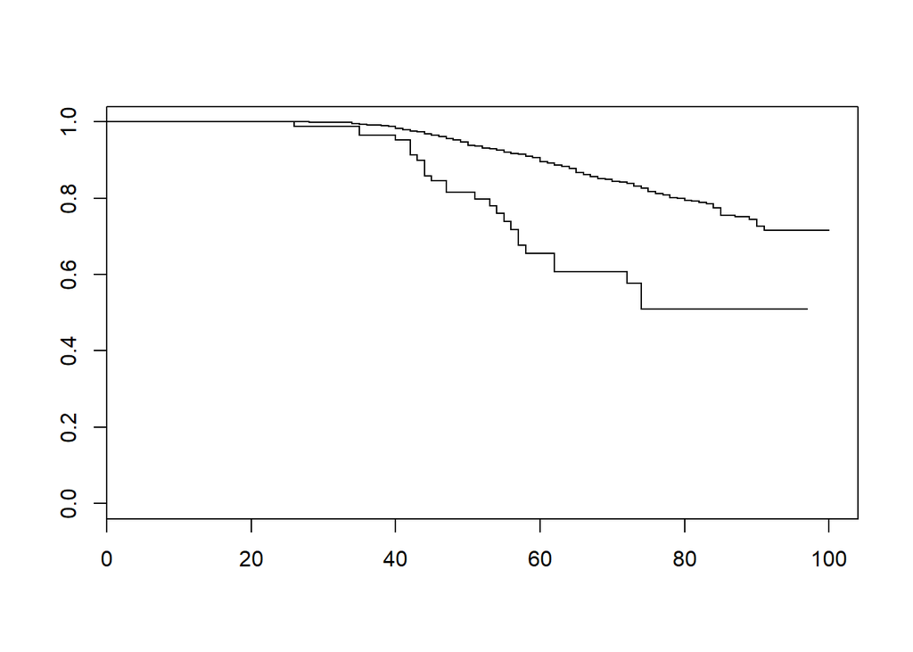

```r
km_mutant <- survfit(bc_surv~ashkenazi$mutant)
plot(km_mutant)
```

```r
coxph(bc_surv~mutant+cluster(famID), data=ashkenazi)
```

```
## Call:
## coxph(formula = bc_surv ~ mutant + cluster(famID), data = ashkenazi)
##
##         coef exp(coef) se(coef) robust se    z     p
## mutant 1.191     3.290    0.198     0.202 5.89 4e-09
##
## Likelihood ratio test=25.9  on 1 df, p=3.55e-07
## n= 3920, number of events= 473
```

```r
cox_frailty <- coxph(
  bc_surv~mutant+frailty(famID),
  data=ashkenazi)
cox_frailty
```

```
## Call:
## coxph(formula = bc_surv ~ mutant + frailty(famID), data = ashkenazi)
##
##                   coef se(coef)     se2   Chisq  DF     p
## mutant           1.272    0.232   0.200  30.134   1 4e-08
## frailty(famID)                          221.500 212  0.31
##
## Iterations: 6 outer, 26 Newton-Raphson
##      Variance of random effect= 0.494   I-likelihood = -3564.3
## Degrees of freedom for terms=   0.7 211.6
## Likelihood ratio test=400  on 212 df, p=1.17e-13  n= 3920
```

```r
cox_frailty2 <- coxme(
  bc_surv~mutant+(1 | famID),
  data=ashkenazi)
cox_frailty2
```

```
## Cox mixed-effects model fit by maximum likelihood
##   Data: ashkenazi
##   events, n = 473, 3920
##   Iterations= 10 63
##                     NULL Integrated    Fitted
## Log-likelihood -3579.707  -3564.622 -3411.522
##
##                    Chisq    df          p   AIC     BIC
## Integrated loglik  30.17   2.0 2.8100e-07 26.17   17.85
##  Penalized loglik 336.37 150.1 2.2204e-16 36.16 -588.13
##
## Model:  bc_surv ~ mutant + (1 | famID)
## Fixed coefficients
##            coef exp(coef)  se(coef)    z       p
## mutant 1.236609  3.443914 0.2205358 5.61 2.1e-08
##
## Random effects
##  Group Variable  Std Dev   Variance
##  famID Intercept 0.5912135 0.3495334
```

```r
head(rats)
```

```
##   litter rx time status sex
## 1      1  1  101      0   f
## 2      1  0   49      1   f
## 3      1  0  104      0   f
## 4      2  1   91      0   m
## 5      2  0  104      0   m
## 6      2  0  102      0   m
```

```r
summary(rats)
```

```
##      litter             rx              time            status
##  Min.   :  1.00   Min.   :0.0000   Min.   : 23.00   Min.   :0.00
##  1st Qu.: 25.75   1st Qu.:0.0000   1st Qu.: 80.75   1st Qu.:0.00
##  Median : 50.50   Median :0.0000   Median : 98.00   Median :0.00
##  Mean   : 50.50   Mean   :0.3333   Mean   : 90.44   Mean   :0.14
##  3rd Qu.: 75.25   3rd Qu.:1.0000   3rd Qu.:104.00   3rd Qu.:0.00
##  Max.   :100.00   Max.   :1.0000   Max.   :104.00   Max.   :1.00
##      sex
##  Length:300
##  Class :character
##  Mode  :character
##
##
##
```

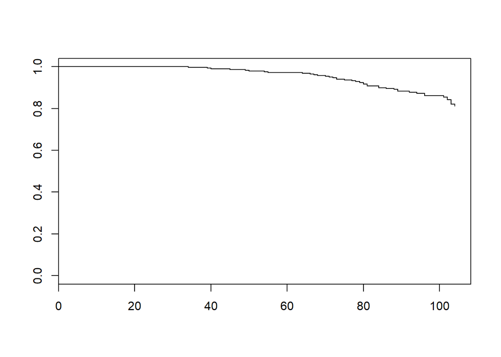

```r
rats_surv <- Surv(rats$time, rats$status)
overall_km <- survfit(rats_surv~1)
plot(overall_km, conf.int=FALSE)
```

```r
coxph(
  rats_surv~rx+sex+cluster(litter),
  data=rats)
```

```
## Call:
## coxph(formula = rats_surv ~ rx + sex + cluster(litter), data = rats)
##
##         coef exp(coef) se(coef) robust se     z       p
## rx    0.7910    2.2056   0.3094    0.2927  2.70  0.0069
## sexm -3.0677    0.0465   0.7248    0.7207 -4.26 2.1e-05
##
## Likelihood ratio test=50  on 2 df, p=1.36e-11
## n= 300, number of events= 42
```

```r
coxph(
  rats_surv~rx+sex+frailty(litter),
  data=rats)
```

```
## Call:
## coxph(formula = rats_surv ~ rx + sex + frailty(litter), data = rats)
##
##                   coef se(coef)    se2  Chisq   DF     p
## rx               0.795    0.314  0.310  6.412  1.0 0.011
## sexm            -3.144    0.737  0.726 18.177  1.0 2e-05
## frailty(litter)                        17.592 14.6 0.262
##
## Iterations: 6 outer, 29 Newton-Raphson
##      Variance of random effect= 0.466   I-likelihood = -199.5
## Degrees of freedom for terms=  1.0  1.0 14.6
## Likelihood ratio test=79.7  on 16.6 df, p=2.99e-10  n= 300
```

```r
library(timereg)
data(diabetes)
head(diabetes)
```

```
##   id     time status trteye treat adult agedx
## 1  5 46.24967      0      2     1     2    28
## 2  5 46.27553      0      2     0     2    28
## 3 14 42.50684      0      1     1     1    12
## 4 14 31.34145      1      1     0     1    12
## 5 16 42.30098      0      1     1     1     9
## 6 16 42.27406      0      1     0     1     9
```

```r
table(table(diabetes$id))
```

```
##
##   2
## 197
```

```r
summary(diabetes$time)
```

```
##    Min. 1st Qu.  Median    Mean 3rd Qu.    Max.
##  0.3154 13.9851 38.8293 35.6105 54.2951 75.0260
```

```r
table(diabetes$status)
```

```
##
##   0   1
## 239 155
```

```r
table(diabetes$trteye)
```

```
##
##   1   2
## 178 216
```

```r
table(diabetes$treat)
```

```
##
##   0   1
## 197 197
```

```r
table(diabetes$adult)
```

```
##
##   1   2
## 228 166
```

```r
summary(diabetes$agedx)
```

```
##    Min. 1st Qu.  Median    Mean 3rd Qu.    Max.
##    1.00   10.00   16.00   20.78   30.00   58.00
```

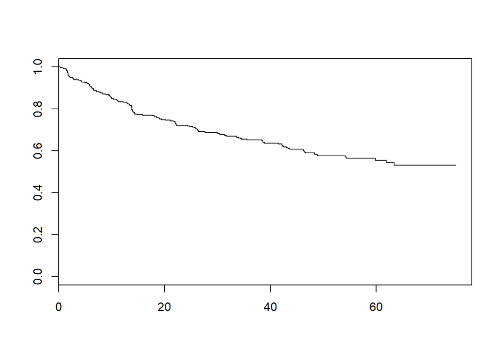

```r
diabetes_surv <- Surv(diabetes$time, diabetes$status)
km_overall <- survfit(diabetes_surv~1)
plot(km_overall, conf.int=FALSE)
```

```r
coxph(
  diabetes_surv~treat+agedx+cluster(id),
  data=diabetes)
```

```
## Call:
## coxph(formula = diabetes_surv ~ treat + agedx + cluster(id),
##     data = diabetes)
##
##           coef exp(coef) se(coef) robust se     z       p
## treat -0.78216   0.45742  0.16897   0.14834 -5.27 1.3e-07
## agedx  0.00403   1.00404  0.00547   0.00626  0.64    0.52
##
## Likelihood ratio test=22.9  on 2 df, p=1.06e-05
## n= 394, number of events= 155
```

```r
coxph(
  diabetes_surv~treat+agedx+frailty(id),
  data=diabetes)
```

```
## Call:
## coxph(formula = diabetes_surv ~ treat + agedx + frailty(id),
##     data = diabetes)
##
##                  coef  se(coef)       se2     Chisq DF       p
## treat        -0.91642   0.17445   0.17136  27.59594  1 1.5e-07
## agedx         0.00542   0.00747   0.00565   0.52783  1   0.468
## frailty(id)                               113.86639 84   0.017
##
## Iterations: 6 outer, 30 Newton-Raphson
##      Variance of random effect= 0.851   I-likelihood = -850.6
## Degrees of freedom for terms=  1.0  0.6 84.0
## Likelihood ratio test=202  on 85.5 df, p=2.37e-11  n= 394
```

The kidney data set contains information on catheter infections, and is available within the survival package of R.

```r
par(mar=c(2.6, 2.6, 0.6, 0.6))
head(kidney)
```

```
##   id time status age sex disease frail
## 1  1    8      1  28   1   Other   2.3
## 2  1   16      1  28   1   Other   2.3
## 3  2   23      1  48   2      GN   1.9
## 4  2   13      0  48   2      GN   1.9
## 5  3   22      1  32   1   Other   1.2
## 6  3   28      1  32   1   Other   1.2
```

```r
table(table(kidney$id))
```

```
##
##  2
## 38
```

```r
table(kidney$status)
```

```
##
##  0  1
## 18 58
```

```r
table(kidney$sex)
```

```
##
##  1  2
## 20 56
```

```r
table(kidney$disease)
```

```
##
## Other    GN    AN   PKD
##    26    18    24     8
```

```r
summary(kidney$time)
```

```
##    Min. 1st Qu.  Median    Mean 3rd Qu.    Max.
##     2.0    16.0    39.5   101.6   149.8   562.0
```

```r
summary(kidney$age)
```

```
##    Min. 1st Qu.  Median    Mean 3rd Qu.    Max.
##    10.0    34.0    45.5    43.7    54.0    69.0
```

```r
summary(kidney$frail)
```

```
##    Min. 1st Qu.  Median    Mean 3rd Qu.    Max.
##   0.200   0.600   1.100   1.184   1.500   3.000
```

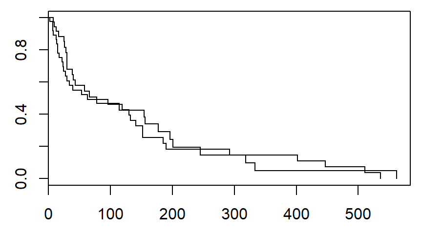

```r
kidney2 <- kidney
kidney2$s <- rep(1:2, 38)
kidney_surv <- Surv(kidney2$time, kidney2$status)
overall_km <- survfit(kidney_surv~kidney2$s)
plot(overall_km, conf.int=FALSE)
```

```r
coxph(
  kidney_surv~age+sex+disease+cluster(id),
  data=kidney2)
```

```
## Call:
## coxph(formula = kidney_surv ~ age + sex + disease + cluster(id),
##     data = kidney2)
##
##                coef exp(coef) se(coef) robust se     z       p
## age         0.00318   1.00319  0.01115   0.00719  0.44 0.65842
## sex        -1.48314   0.22692  0.35823   0.40085 -3.70 0.00022
## diseaseGN   0.08796   1.09194  0.40637   0.28699  0.31 0.75924
## diseaseAN   0.35079   1.42020  0.39972   0.27497  1.28 0.20204
## diseasePKD -1.43111   0.23904  0.63111   0.87132 -1.64 0.10050
##
## Likelihood ratio test=17.6  on 5 df, p=0.00342
## n= 76, number of events= 58
```

```r
coxph(
  kidney_surv~age+sex+disease+strata(s)+cluster(id),
  data=kidney2)
```

```
## Call:
## coxph(formula = kidney_surv ~ age + sex + disease + strata(s) +
##     cluster(id), data = kidney2)
##
##                coef exp(coef) se(coef) robust se     z       p
## age         0.00619   1.00621  0.01148   0.00774  0.80   0.424
## sex        -1.66744   0.18873  0.38015   0.38899 -4.29 1.8e-05
## diseaseGN   0.15126   1.16330  0.40974   0.31044  0.49   0.626
## diseaseAN   0.36983   1.44749  0.42033   0.30840  1.20   0.230
## diseasePKD -1.41267   0.24349  0.64496   0.85563 -1.65   0.099
##
## Likelihood ratio test=19.9  on 5 df, p=0.0013
## n= 76, number of events= 58
```

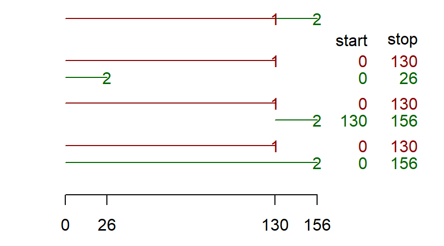

```r
par(mar=c(2.6, 2.6, 0.6, 0.6))
plot_sequence <- function(i) {
  c1 <- "darkred"
  c2 <- "darkgreen"
  kidney2$lb <- ifelse(kidney2$status==1, kidney2$s, "C")
  kidney2                %>%
    filter(id==i)        %>%
    filter(s==1)         %>%
    select(time, lb)     -> t1
  kidney2                %>%
    filter(id==i)        %>%
    filter(s==2)         %>%
    select(time, lb)     -> t2
  t2$time <- ifelse(t1$lb=="C", NA, t2$time)
  tmax <- sum(t1$time,t2$time, na.rm=TRUE)
  plot(c(0, 1.4*tmax), c(10, 50), type="n", axes=FALSE)
  axis(side=1, at=c(0, t1$time, t2$time, tmax))
  segments(0, 50, t1$time, 50, col=c1)
  segments(t1$time, 50, tmax, 50, col=c2)
  text(t1$time, 50, t1$lb, col=c1)
  text(tmax,    50, t2$lb, col=c2)
  text(1.2*tmax, 45, "start", adj=1)
  text(1.4*tmax, 45, "stop", adj=1)

  segments(0, 40, t1$time, 40, col=c1)
  segments(0, 36, t2$time, 36, col=c2)
  text(t1$time, 40, t1$lb, col=c1)
  text(t2$time, 36, t2$lb, col=c2)
  text(1.2*tmax, 40, 0, col=c1, adj=1)
  text(1.4*tmax, 40, t1$time, col=c1, adj=1)
  text(1.2*tmax, 36, 0, col=c2, adj=1)
  text(1.4*tmax, 36, t2$time, col=c2, adj=1)

  segments(0, 30, t1$time, 30, col=c1)
  segments(t1$time, 26, tmax, 26, col=c2)
  text(t1$time, 30, t1$lb, col=c1)
  text(tmax, 26, t2$lb, col=c2)
  text(1.2*tmax, 30, 0, col=c1, adj=1)
  text(1.4*tmax, 30, t1$time, col=c1, adj=1)
  text(1.2*tmax, 26, t1$time, col=c2, adj=1)
  text(1.4*tmax, 26, tmax, col=c2, adj=1)

  segments(0, 20, t1$time, 20, col=c1)
  segments(0, 16, tmax, 16, col=c2)
  text(t1$time, 20, t1$lb, col=c1)
  text(tmax, 16, t2$lb, col=c2)
  text(1.2*tmax, 20, 0, col=c1, adj=1)
  text(1.4*tmax, 20, t1$time, col=c1, adj=1)
  text(1.2*tmax, 16, 0, col=c2, adj=1)
  text(1.4*tmax, 16, tmax, col=c2, adj=1)
}
plot_sequence(30)
```

Save everything for possible later re-use.

```r
save.image("~/survival-models/bin/supplement-7.RData")
```